# Homework:Probability

Carlos Rodriguez

8/30/2017

## R Markdown

1. At a county fair carnival game, there are 25 balloons on a board, 10 of which are yellow, 8 red, and 7 green. Given that the first balloon hit is yellow, what is the probability that the next balloon hit will also be yellow?

Total = 25 1st hit = Yellow Yellow = 9 and Total = 24 Probability = 9/24 = 3/8 = .375 P(Y|T) = P(Y∩T)/P(T) = .375

2. After randomly assigning 60 guinea pigs to receive one of three dose levels of vitamin C (0.5, 1, and 2 mg/day) by one of two supplements, orange juice (OJ) or ascorbic acid (a form of vitamin C encoded as VC), researchers recorded the length of odontoblasts (cells responsible for tooth growth).
- Is this an experiment or an observational study? Explain.

This is an experiment since the dose of the vitamin was randomly given to the guinea pigs from different forms of supplement.

- State why the following plot shows that on average OJ causes higher odontoblast length than does VC.

Looking from the plot given the OJ seems to have a higher average overall even though on the 2 mg/day seems to be shorter length. Also based on the median the median for each seems to be higher with OJ and on the 2 mg/day the median is equal -Provide the R code to reproduce the plot above in full. ## Including Plots

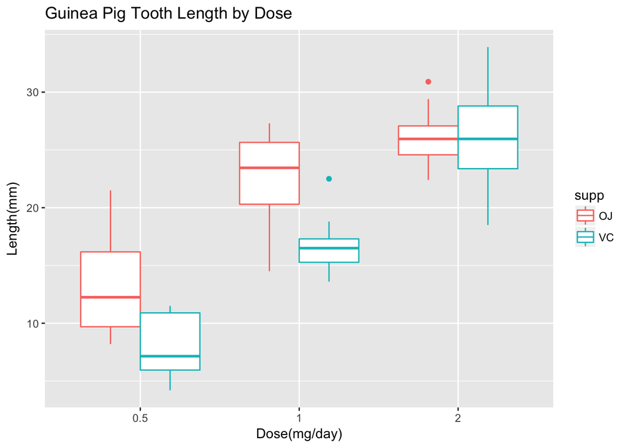

```r
suppressMessages(library(tidyverse))
qplot(factor(dose), len, data=ToothGrowth, xlab = "Dose(mg/day)", ylab = "Length(mm)", geom="boxplot", colour=supp, main="Guinea Pig Tooth Length by Dose")
```

- Justify my use of the word causes in part b.

  We identified that this was an experimen so the use of cause can be used because there seems to be a relationship between the dose given and the form of supplement.
3. Refer to the Systems Reliability section of the slides ProbabilityExamples. Suppose the sequential system happens before the parallel system, such that the output of the sequential system is the input to the parallel system. What is the probability of failure of this new complete system? The individual components have probabilities of success and failure independent of each other, as follows.

```r
event <- matrix(c(0.9, 0.85, 0.8, 0.1, 0.15, 0.2, 0.1, 0.15, 0.2, 0.9, 0.85, 0.8), ncol=6, byrow = TRUE)
colnames(event) <- c("A","B","C","D","E","F")
rownames(event) <- c("success","failure")
event <- as.table(event)
event
```

```
##            A    B    C    D    E    F
## success 0.90 0.85 0.80 0.10 0.15 0.20
## failure 0.10 0.15 0.20 0.90 0.85 0.80
```

P(success) P(parallel_fails) 1-P(success) = 1 - (P(succeed_consecutive) * (1-P(parallel_fails)))

```
                        1- (0.9 * 0.85 * 0.8) * (1- (0.9)* 0.85 * 0.8)

                        = .76
```

4. Using the dataset groceries, calculate the support, confidence, and lift of the following association rules. Answers can be found in the leture ProbabilityExamples. Since I’m providing the answers, what counts here is your R code.

• {curd, cereals} → {wholemilk} • {yogurt, cereals} → {wholemilk} • {liquor, red/blushwine} → {bottledbeer}

```r
suppressMessages(library(arules))
data(Groceries)
arGroceries <- apriori(Groceries, parameter=list(supp=0.001, conf=0.8))
```

[output not shown]

```r
inspect(head(arGroceries, n=3))
```

```
##     lhs                        rhs            support     confidence
## [1] {liquor,red/blush wine} => {bottled beer} 0.001931876 0.9047619
## [2] {curd,cereals}          => {whole milk}   0.001016777 0.9090909
## [3] {yogurt,cereals}        => {whole milk}   0.001728521 0.8095238
##     lift
## [1] 11.235269
## [2]  3.557863
## [3]  3.168192
```